# Practical machine learning project coursework

Flavie

April 26, 2016

## Background (from Coursera)

Using devices such as Jawbone Up, Nike FuelBand, and Fitbit it is now possible to collect a large amount of data about personal activity relatively inexpensively. These type of devices are part of the quantified self movement - a group of enthusiasts who take measurements about themselves regularly to improve their health, to find patterns in their behavior, or because they are tech geeks. One thing that people regularly do is quantify how much of a particular activity they do, but they rarely quantify how well they do it. In this project, your goal will be to use data from accelerometers on the belt, forearm, arm, and dumbell of 6 participants. They were asked to perform barbell lifts correctly and incorrectly in 5 different ways. More information is available from the website here: http://groupware.les.inf.puc-rio.br/har (see the section on the Weight Lifting Exercise Dataset).

## Objectives of exercise

The goal is to predict the manner in which the participantsdid the exercise. This is the “classe” variable in the training set. We may use any of the other variables to predict with. We should create a report describing how you built your model, how we used cross validation, what we think the expected out of sample error is, and why we made the choices you did. You will also use our prediction model to predict 20 different test cases.

The following packages are needed to perform the analyses

```r
library(caret)
library(randomForest)
```

## 1. Tidy data

First, we download the data and read them into R while specifying that all instances of “#DIV/0” should be considered NAs.

```r
download.file(url = "https://d396qusza40orc.cloudfront.net/predmachlearn/pml-training.csv", destfile = "pml-training.csv")
download.file(url = "https://d396qusza40orc.cloudfront.net/predmachlearn/pml-testing.csv", destfile = "pml-testing.csv")

pmltrain <- read.csv("pml-training.csv",na.strings=c("#DIV/0!"), row.names = 1)
pmltest <- read.csv("pml-testing.csv",na.strings=c("#DIV/0!"), row.names = 1)
```

We plot the distribution of our outcome variable, classe, a factor variable with 5 levels. Class A corresponds to the correct execution of an exercise, while the other 4 classes correspond to common mistakes.

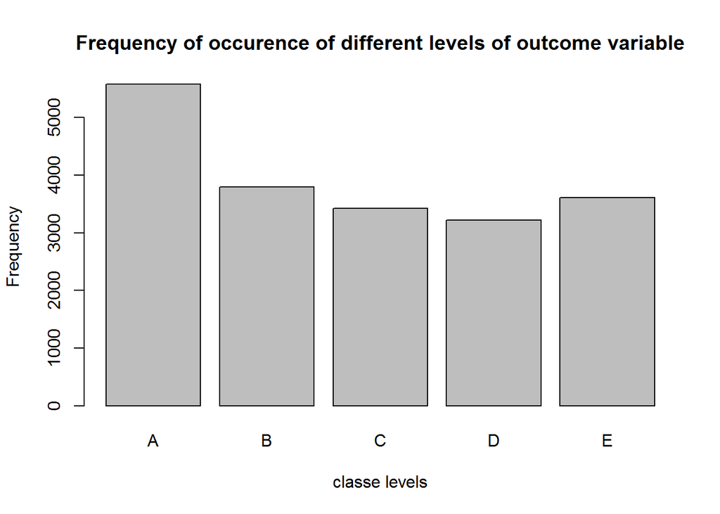

```r
training<-pmltrain[, -c(1:7)]

treshold <- dim(training)[1] * 0.20
keep_col <- !apply(training, 2, function(x) sum(is.na(x)) > treshold  || sum(x=="") > treshold)
training <- training[, keep_col]

nzv_col <- nearZeroVar(training)
training <- training[, -nzv_col]


plot(training$classe, col="grey", main="Frequency of occurence of different levels of outcome variable", xlab="classe levels", ylab="Frequency")
```

## 2. Create dataset for cross validation

Cross-validation will be performed by subsampling our training data set randomly without replacement into 2 subsamples: subTraining data (60% of the original Training data set) and Validation data (40%).

```r
set.seed(123)
trainset <- createDataPartition(training$classe, p = 0.6, list = FALSE)
subTraining <- training[trainset, ]
Validation <- training[-trainset, ]
```

Our models will be fitted on the subTraining data set, and tested on the Validation data. Once the most accurate model is choosen, it will be tested on the original Testing data set.

## 3. Apply random forest model

We will apply a random forest model on the subTraining data set and make predictions on Validation data set. Random forests are suitable when handling a large number of explanatory variables whose interactions is unknown.

```r
my_model<- randomForest(classe ~.,data=subTraining,na.action=na.omit,importance=T)
my_predict <- predict(my_model, Validation)

confusionMatrix(my_predict, Validation$classe)
```

```
## Confusion Matrix and Statistics
##
##           Reference
## Prediction    A    B    C    D    E
##          A 2231    9    0    0    0
##          B    1 1506   11    0    0
##          C    0    3 1354   17    3
##          D    0    0    3 1269    4
##          E    0    0    0    0 1435
##
## Overall Statistics
##
##                Accuracy : 0.9935
##                  95% CI : (0.9915, 0.9952)
##     No Information Rate : 0.2845
##     P-Value [Acc > NIR] : < 2.2e-16
##
##                   Kappa : 0.9918
##  Mcnemar's Test P-Value : NA
##
## Statistics by Class:
##
##                      Class: A Class: B Class: C Class: D Class: E
## Sensitivity            0.9996   0.9921   0.9898   0.9868   0.9951
## Specificity            0.9984   0.9981   0.9964   0.9989   1.0000
## Pos Pred Value         0.9960   0.9921   0.9833   0.9945   1.0000
## Neg Pred Value         0.9998   0.9981   0.9978   0.9974   0.9989
## Prevalence             0.2845   0.1935   0.1744   0.1639   0.1838
## Detection Rate         0.2843   0.1919   0.1726   0.1617   0.1829
## Detection Prevalence   0.2855   0.1935   0.1755   0.1626   0.1829
## Balanced Accuracy      0.9990   0.9951   0.9931   0.9929   0.9976
```

Although many explanatory variables were included in the model, they did not equally contribute to the outcome classification, as the plot below illustrates (higher value mean more important)

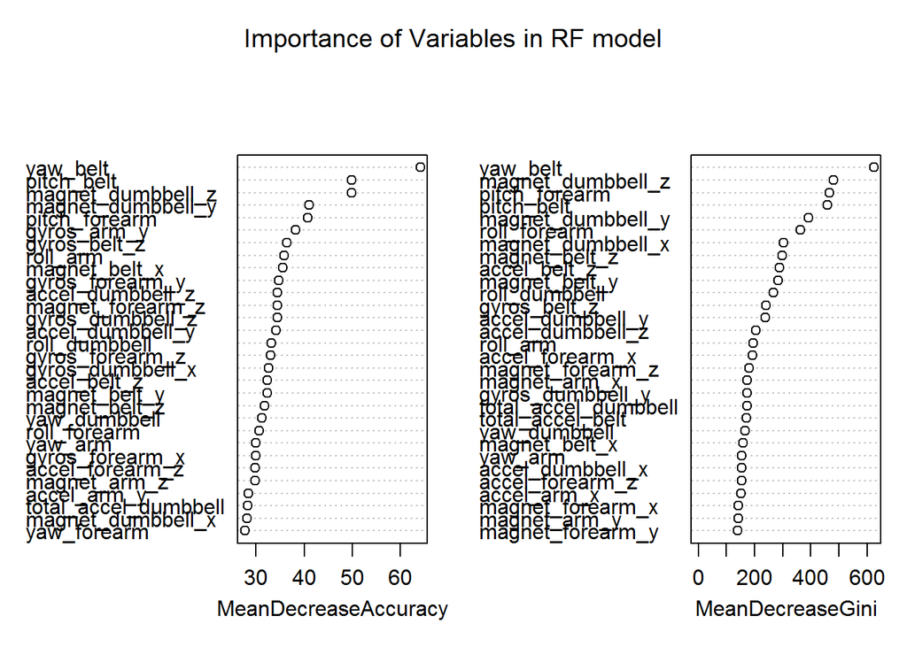

```r
varImpPlot(my_model,main = "Importance of Variables in RF model")
```

## 4. Predictions on test set

We will now predict outcome levels on the original Testing data set using the same RF model.

```r
predict_test <- predict(my_model, pmltest)
predict_test
```

```
##  1  2  3  4  5  6  7  8  9 10 11 12 13 14 15 16 17 18 19 20
##  B  A  B  A  A  E  D  B  A  A  B  C  B  A  E  E  A  B  B  B
## Levels: A B C D E
```